# Dates

# The correct data format: YYYY-MM-DD

[figure not shown]

# Converting to `Date` class

You can convert character data to `Date` class with `as.Date()`:

```r
dchar <- "2018-10-12"
ddate <- as.Date(dchar)
```

# Class

```r
dchar
```

```
## [1] "2018-10-12"
```

```r
ddate
```

```
## [1] "2018-10-12"
```

```r
class(dchar)
```

```
## [1] "character"
```

```r
class(ddate)
```

```
## [1] "Date"
```

# Specifying the format

```r
as.Date("Thursday, January 6, 2005", format = "%A, %B %d, %Y")
```

```
## [1] "2005-01-06"
```

For a list of the conversion specifications available in R, see `?strptime`.

# parse_date

similar to `as.Date()`, more strict but some options aren’t implemented

```r
as.Date("1/12/2019", format="%m/%d/%y")
```

```
## [1] "2020-01-12"
```

```r
readr::parse_date("1/12/2019", format="%m/%d/%y")
```

```
## [1] NA
```

```r
as.Date("Thursday, January 6, 2005", format = "%A, %B %d, %Y")
```

```
## [1] "2005-01-06"
```

```r
readr::parse_date("Thursday, January 6, 2005", format = "%A, %B %d, %Y")
```

```
## Error: Invalid %A auto parser
```

See `?parse_date`

# Challenge

Convert **Date: Mon, Mar-15-2021** to Date class using `as.Date()`

First person to complete in the chat window gets a virtual dessert treat

# lubridate package

The tidyverse **lubridate** makes it easy to convert dates that are not in standard format with `ymd()`, `ydm()`, `mdy()`, `myd()`, `dmy()`, and `dym()` (among many other useful date-time functions):

```r
lubridate::mdy("April 13, 1907")
```

```
## [1] "1907-04-13"
```

# Working with `Date` Class

It is well worth the effort to convert to `Date` class, because there’s a lot you can do with dates in a `Date` class that you can’t do if you store the dates as character data.

Number of days between dates:

```r
as.Date("2017-11-02") - as.Date("2017-01-01")
```

```
## Time difference of 305 days
```

# Compare dates

```r
as.Date("2017-11-12") > as.Date("2017-3-3")
```

```
## [1] TRUE
```

Note that `Sys.Date()` returns today’s date as a `Date` class:

```r
Sys.Date()
```

```
## [1] "2021-10-25"
```

```r
class(Sys.Date())
```

```
## [1] "Date"
```

# base R functions

```r
today <- Sys.Date()
weekdays(today, abbreviate = TRUE)
```

```
## [1] "Mon"
```

```r
months(today, abbreviate = TRUE)
```

```
## [1] "Oct"
```

```r
quarters(today)
```

```
## [1] "Q4"
```

# lubridate functions

The **lubridate** package provides additional functions to extract information from a date:

```r
today <- Sys.Date()
lubridate::year(today)
```

```
## [1] 2021
```

```r
lubridate::yday(today)
```

```
## [1] 298
```

```r
lubridate::month(today, label = TRUE)
```

```
## [1] Oct
## 12 Levels: Jan < Feb < Mar < Apr < May < Jun < Jul < Aug < Sep < ... < Dec
```

```r
lubridate::week(today)
```

```
## [1] 43
```

# Plotting with a `Date` class variable

Both base R graphics and **ggplot2** “know” how to work with a `Date` class variable, and label the axes properly:

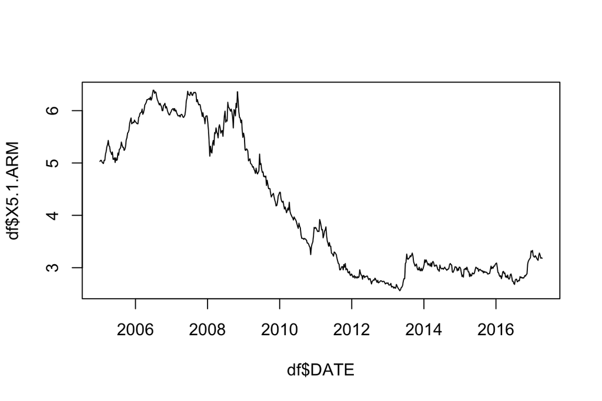

```r
df <- read.csv("mortgage.csv")
df$DATE <- as.Date(df$DATE)
plot(df$DATE, df$X5.1.ARM, type = "l") # on the order of years
```

# base R

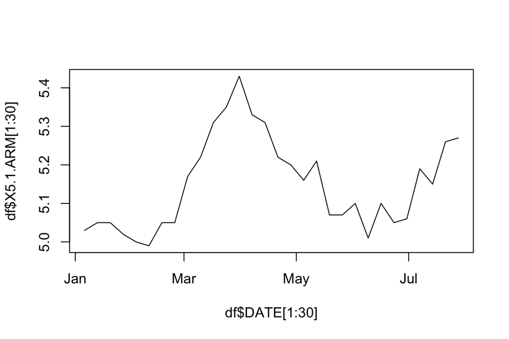

```r
plot(df$DATE[1:30], df$X5.1.ARM[1:30], type = "l") # switch to months
```

# ggplot2

```r
# readr
library(tidyverse)
```

Note that unlike base R `read.csv()`, `readr::read_csv()` automatically reads DATE in as a `Date` class since it’s in YYYY-MM-DD format:

```r
df <- readr::read_csv("mortgage.csv")
glimpse(df)
```

```
## Rows: 641
## Columns: 4
## $ DATE          <date> 2005-01-06, 2005-01-13, 2005-01-20, 2005-01-27, 2005-02…
## $ `5/1 ARM`     <dbl> 5.03, 5.05, 5.05, 5.02, 5.00, 4.99, 5.05, 5.05, 5.17, 5.…
## $ `15 YR FIXED` <dbl> 5.21, 5.19, 5.15, 5.14, 5.14, 5.10, 5.14, 5.22, 5.33, 5.…
## $ `30 YR FIXED` <dbl> 5.77, 5.74, 5.67, 5.66, 5.63, 5.57, 5.62, 5.69, 5.79, 5.…
```

# ggplot2

```r
g <- ggplot(df, aes(DATE, `30 YR FIXED`)) +
  geom_line() +
  theme_grey(14)
```

# ggplot2

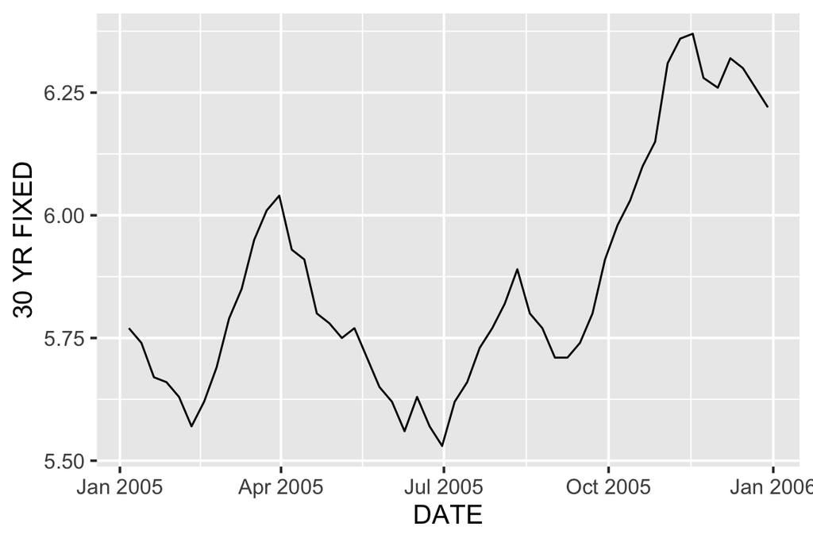

```r
ggplot(df %>% filter(DATE < as.Date("2006-01-01")),
       aes(DATE, `30 YR FIXED`)) +
  geom_line() +
  theme_grey(14)
```

Again, when the data is filtered, the x-axis labels switch from years to months.

# Limits

We can control the x-axis breaks, limits, and labels with `scale_x_date()`:

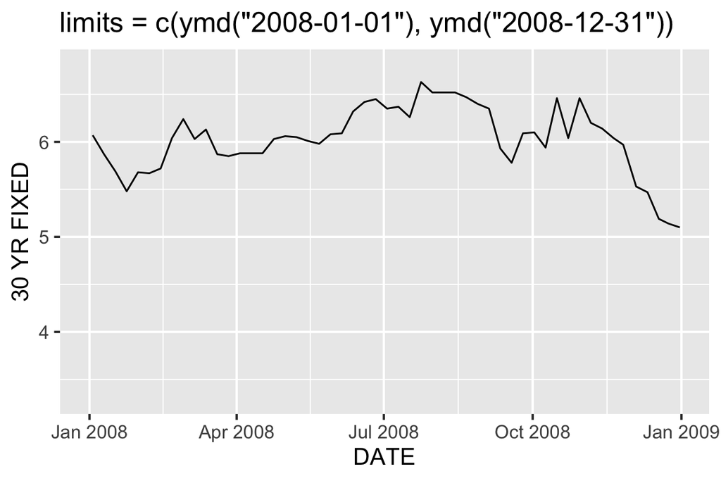

```r
library(lubridate)
g + scale_x_date(limits = c(ymd("2008-01-01"), ymd("2008-12-31"))) +
  ggtitle("limits = c(ymd(\"2008-01-01\"), ymd(\"2008-12-31\"))")
```

# Breaks

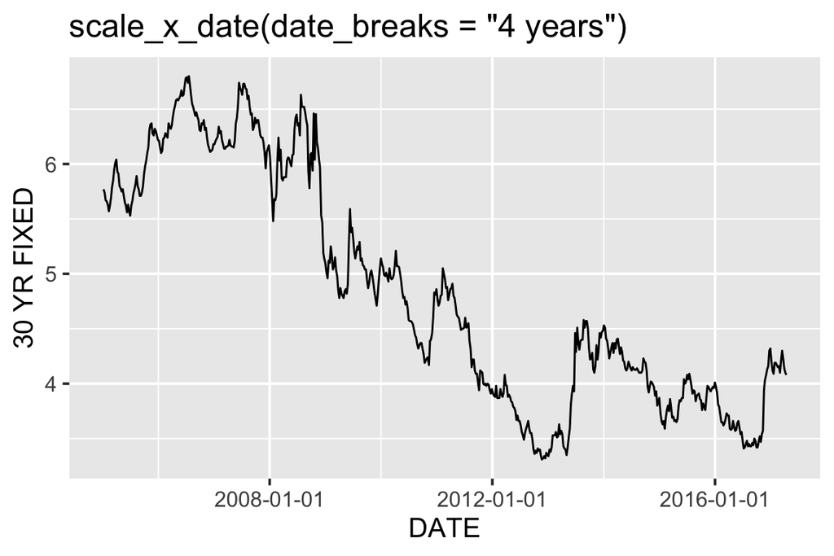

```r
g + scale_x_date(date_breaks = "4 years") +
  ggtitle("scale_x_date(date_breaks = \"4 years\")")
```

# Labels

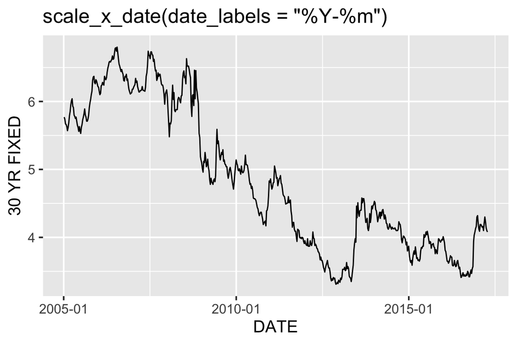

```r
g + scale_x_date(date_labels = "%Y-%m") +
  ggtitle("scale_x_date(date_labels = \"%Y-%m\")")
```

(Remember `?parse_date` and `?strptime` for help.)

# Annotations

We can use `geom_vline()` with `annotate()` to mark specific events in a time series:

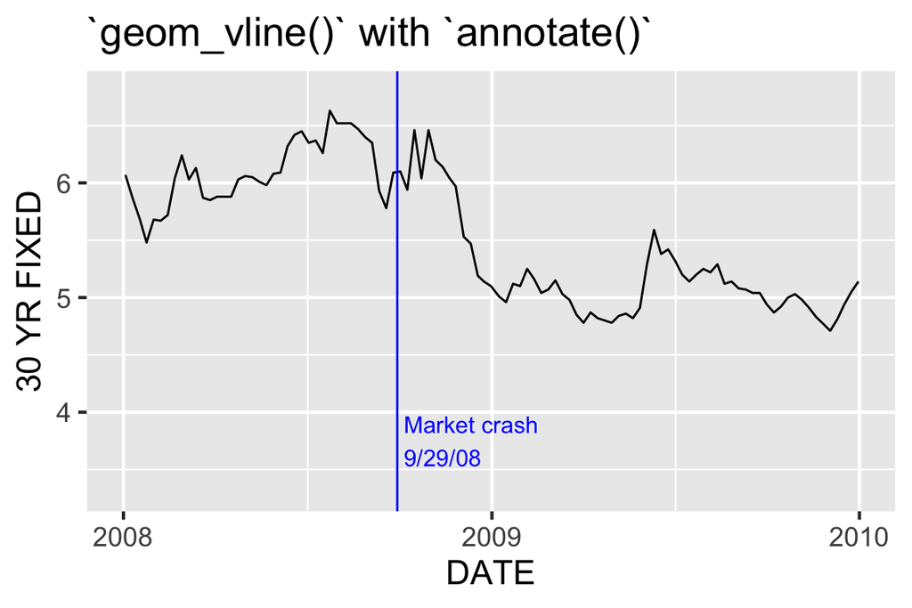

```r
ggplot(df, aes(DATE, `30 YR FIXED`)) +
  geom_line() +
  geom_vline(xintercept = ymd("2008-09-29"), color = "blue") +
  annotate("text", x = ymd("2008-09-29"), y = 3.75,
           label = " Market crash\n 9/29/08", color = "blue",
           hjust = 0) +
  scale_x_date(limits = c(ymd("2008-01-01"), ymd("2009-12-31")),
               date_breaks = "1 year",
               date_labels = "%Y") +
  theme_grey(16) +
  ggtitle("`geom_vline()` with `annotate()`")
```